# chapter 4 question 1

## Chapter 4

## Question 1

Part 1:Downloaded song from the website. Song Name : Tibetan Singing Bowl (Struck)  
Part 2:Download a few of these files and compute the spectrum of each signal.  
Part 3:Does the power spectrum look like white noise, pink noise, or Brownian noise?  
Part 4:How does the spectrum vary over time?

## Question 1. Part 1 :

`A Soft Murmur'' is a web site that plays a mixture of natural noise sources, including rain, waves, wind, etc. At http://asoftmurmur.com/about/ you can find their list of recordings, most of which are at http://freesound.org.

## Libraries

```python
from __future__ import print_function, division

import thinkdsp
import thinkplot
import thinkstats2

import numpy as np
import pandas as pd

import warnings
warnings.filterwarnings('ignore')

from ipywidgets import interact, interactive, fixed
import ipywidgets as widgets

%matplotlib inline
```

## Answer

Downloaded song from the website. Song Name : Tibetan Singing Bowl (Struck)

```python
wave = thinkdsp.read_wave('music/193022__truthiswithin__tibetan-singing-bowl-struck.wav')
wave.make_audio()
```

[interactive chart not shown]

## Question 1: Part 2

Download a few of these files and compute the spectrum of each signal.

## Calculating Spectrum of downloaded song

Step 1: Segmenting the downloaded wave

```python
segment = wave.segment(start=1.5, duration=1.0)
```

Step 2: Converting the segmented wave to audio

```python
segment.make_audio()
```

[interactive chart not shown]

Step 3: Calculating Spectrum of the signal

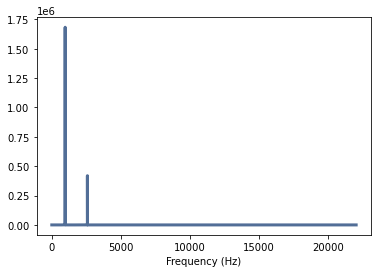

```python
spectrum = segment.make_spectrum()
spectrum.plot_power()
thinkplot.config(xlabel='Frequency (Hz)')
```

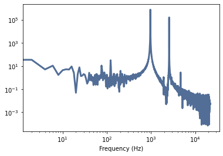

```python
spectrum.plot_power()
thinkplot.config(xlabel='Frequency (Hz)',
                 xscale='log',
                 yscale='log')
```

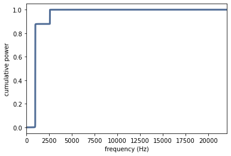

```python
integ_down = spectrum.make_integrated_spectrum()
integ_down.plot_power()
thinkplot.config(xlabel='frequency (Hz)',
                ylabel='cumulative power',
                xlim=[0, spectrum.fs[-1]])
```

## Question 1 : Part 3

```
Does the power spectrum look like white noise, pink noise, or Brownian noise?
```

## A brief introduction related to White noise, Pink noise, Brownian noise signals

## White Noise :

In signal processing, white noise is a random signal having equal intensity at different frequencies, giving it a constant power spectral density.

Step 1: Generating a simple uncorrelated simple noise

```python
signal_gen = thinkdsp.UncorrelatedUniformNoise()
wave_gen = signal_gen.make_wave(duration=0.5, framerate=11025)
wave_gen.make_audio()
```

[interactive chart not shown]

Step 2: segmenting the generated wave

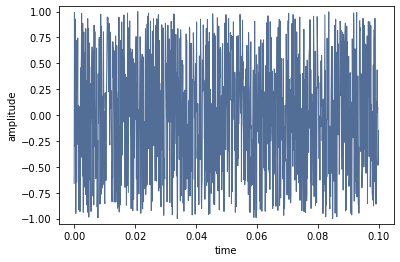

```python
segment_gen = wave_gen.segment(duration=0.1)
segment_gen.plot(linewidth=1)
thinkplot.config(xlabel='time',
                 ylabel='amplitude',
                 ylim=[-1.05, 1.05],
                 legend=False)
```

Step 3: Calculating spectrum of generated wave

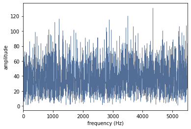

```python
spectrum_gen = wave_gen.make_spectrum()
spectrum_gen.plot(linewidth=0.5)
thinkplot.config(xlabel='frequency (Hz)',
                 ylabel='amplitude',
                 xlim=[0, spectrum_gen.fs[-1]])
```

Step 4: Checking whether the generated wave signal contains white noise or not.  
If white noise  
then a straight line

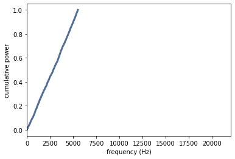

```python
integ = spectrum_gen.make_integrated_spectrum()
integ.plot_power()
thinkplot.config(xlabel='frequency (Hz)',
                ylabel='cumulative power',
                xlim=[0, spectrum.fs[-1]])
```

A straight line in this figure indicates that white noise noise has equal power at all frequencies, on average.

## Pink Noise

Pink noise or 1⁄f noise is a signal or process with a frequency spectrum such that the power spectral density (energy or power per frequency interval) is inversely proportional to the frequency of the signal. In pink noise, each octave (halving or doubling in frequency) carries an equal amount of noise energy.

Pink noise is one of the most common signals in biological systems.

Step 1: Generating pink noise signal

```python
signal_pink = thinkdsp.PinkNoise(beta=1)
wave_pink = signal_pink.make_wave(duration=0.5)
wave_pink.make_audio()
```

[interactive chart not shown]

Step 2: segmenting the generated pink wave

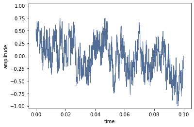

```python
segment_pink = wave_pink.segment(duration=0.1)
segment_pink.plot(linewidth=1)
thinkplot.config(xlabel='time',
                 ylabel='amplitude',
                 ylim=[-1.05, 1.05],
                 legend=False)
```

Step 3: Calculating spectrum of generated pink wave

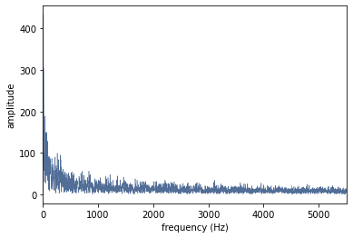

```python
spectrum_pink = wave_pink.make_spectrum()
spectrum_pink.plot(linewidth=0.5)
thinkplot.config(xlabel='frequency (Hz)',
                 ylabel='amplitude',
                 xlim=[0, spectrum_pink.fs[-1]])
```

Step 4: Checking the generated pink signal

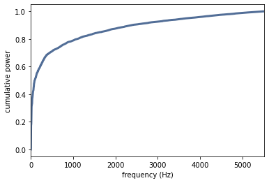

```python
integ_pink = spectrum_pink.make_integrated_spectrum()
integ_pink.plot_power()
thinkplot.config(xlabel='frequency (Hz)',
                ylabel='cumulative power',
                xlim=[0, spectrum_pink.fs[-1]])
```

## Brownian noise

Brownian noise, also known as Brown noise or red noise, is the kind of signal noise produced by Brownian motion, hence its alternative name of random walk noise. The term "Brown noise" does not come from the color, but after Robert Brown, who documented the erratic motion for multiple types of inanimate particles in water. The term "red noise" comes from the "white noise"/"white light" analogy; red noise is strong in longer wavelengths, similar to the red end of the visible spectrum.

Step 1: Generating brownian noise signal

```python
signal_brownian  = thinkdsp.BrownianNoise()
wave_brownian = signal_brownian.make_wave(duration=0.5, framerate=11025)
wave_brownian.make_audio()
```

[interactive chart not shown]

Step 2: segmenting the generated brownian wave

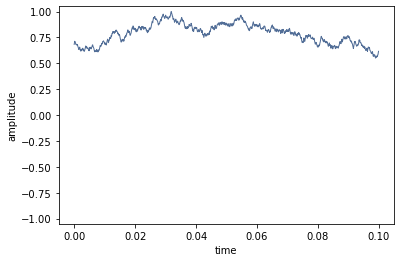

```python
segment_brownian = wave_brownian.segment(duration=0.1)
segment_brownian.plot(linewidth=1)
thinkplot.config(xlabel='time',
                 ylabel='amplitude',
                 ylim=[-1.05, 1.05],
                 legend=False)
```

Step 3: Calculating spectrum of generated brownian wave

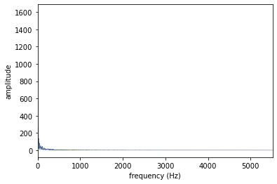

```python
spectrum_brownian = wave_brownian.make_spectrum()
spectrum_brownian.plot(linewidth=0.5)
thinkplot.config(xlabel='frequency (Hz)',
                 ylabel='amplitude',
                 xlim=[0, spectrum_brownian.fs[-1]])
```

Step 4: Checking the generated brownian signal

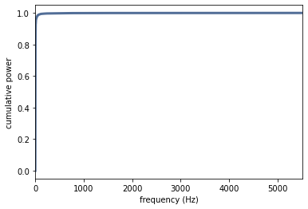

```python
integ_brownian = spectrum_brownian.make_integrated_spectrum()
integ_brownian.plot_power()
thinkplot.config(xlabel='frequency (Hz)',
                ylabel='cumulative power',
                xlim=[0, spectrum_brownian.fs[-1]])
```

## comparing White, Pink and Brownian Noise signal

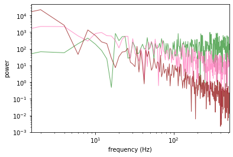

```python
colors = ['#228B22', '#FF69B4', '#8B0000']
betas = [0, 1, 2]

for beta, color in zip(betas, colors):
    signal = thinkdsp.PinkNoise(beta=beta)
    wave = signal.make_wave(duration=0.5, framerate=1024)
    spectrum = wave.make_spectrum()
    spectrum.hs[0] = 0
    spectrum.plot_power(linewidth=1, color=color)

thinkplot.config(xlabel='frequency (Hz)',
                 ylabel='power',
                 xscale='log',
                 yscale='log',
                 xlim=[0, spectrum.fs[-1]])
```

Here  
beta=0 indicate white noise(green color)  
beta=1 indicate pink noise(pink color)  
beta=2 indicate brownian noise(red color)

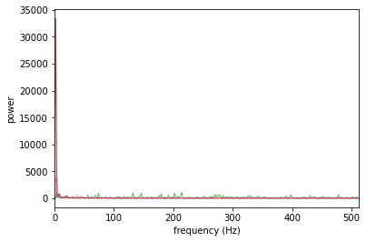

```python
colors = ['#228B22', '#FF69B4', '#8B0000']
betas = [0, 1, 2]

for beta, color in zip(betas, colors):
    signal1 = thinkdsp.PinkNoise(beta=beta)
    wave1 = signal1.make_wave(duration=0.5, framerate=1024)
    spectrum1 = wave1.make_spectrum()
    integ1 = spectrum1.make_integrated_spectrum()
    spectrum1.hs[0] = 0
    spectrum1.plot_power(linewidth=1, color=color)

thinkplot.config(xlabel='frequency (Hz)',
                 ylabel='power',
                 xlim=[0, spectrum1.fs[-1]])
```

## Comparing the downloaded segmented wave signal with white noise, pink noise and brownian noise

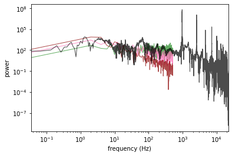

```python
colors = ['#228B22', '#FF69B4', '#8B0000','#000000']
betas = [0, 1, 2,5]

for beta, color in zip(betas, colors):
    if (beta==5):
        segment = wave.segment(start=0.5, duration=0.5)
        spectrum = wave.make_spectrum()
        spectrum.plot_power(linewidth=1, color=color)
    else:
        signal1 = thinkdsp.PinkNoise(beta=beta)
        wave1 = signal1.make_wave(duration=0.5, framerate=1024)
        spectrum1 = wave1.make_spectrum()
        spectrum1.hs[0] = 0
        spectrum1.plot_power(linewidth=1, color=color)

thinkplot.config(xlabel='frequency (Hz)',
                 ylabel='power',
                 xscale='log',
                 yscale='log',
                 xlim=[0, spectrum.fs[-1]])
```

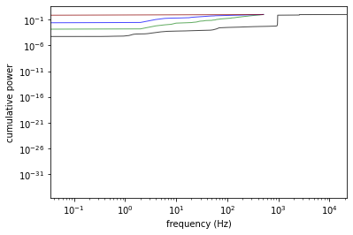

```python
colors = ['#228B22', '#0000FF', '#8B0000','#000000']
betas = [0, 1, 2,5]

for beta, color in zip(betas, colors):
    if (beta==5):
        segment = wave.segment(start=0.5, duration=0.5)
        spectrum1 = wave.make_spectrum()
        intego = spectrum1.make_integrated_spectrum()
        intego.plot_power(linewidth=1, color=color)
    else:
        signal1 = thinkdsp.PinkNoise(beta=beta)
        wave1 = signal1.make_wave(duration=0.5, framerate=1024)
        spectrum1 = wave1.make_spectrum()
        integ1 = spectrum1.make_integrated_spectrum()
        integ1.plot_power(linewidth=1, color=color)

thinkplot.config(xlabel='frequency (Hz)',
                 ylabel='cumulative power',
                 xscale='log',
                 yscale='log',
                 xlim=[0, spectrum1.fs[-1]])
```

Here  
beta=0 indicate white noise(green color)  
beta=1 indicate pink noise(blue color)  
beta=2 indicate brownian noise(red color)  
beta=5 indicate downloaded wave signal(black color)

## Result without log function

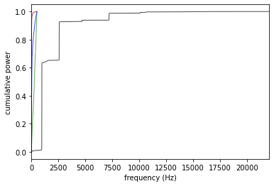

```python
colors = ['#228B22', '#0000FF', '#8B0000','#000000']
betas = [0, 1, 2,5]

for beta, color in zip(betas, colors):
    if (beta==5):
        segment = wave.segment(start=0.0, duration=0.5)
        spectrum1 = segment.make_spectrum()
    else:
        signal1 = thinkdsp.PinkNoise(beta=beta)
        wave1 = signal1.make_wave(duration=0.5, framerate=1024)
        spectrum1 = wave1.make_spectrum()
    integ1 = spectrum1.make_integrated_spectrum()
    integ1.plot_power(linewidth=1, color=color)

thinkplot.config(xlabel='frequency (Hz)',
                 ylabel='cumulative power',
                 xlim=[0, spectrum1.fs[-1]])
```

Here  
beta=0 indicate white noise(green color)  
beta=1 indicate pink noise(blue color)  
beta=2 indicate brownian noise(red color)  
beta=5 indicate downloaded wave signal(black color)

## Question 1 part 4

How does the spectrum vary over time?

Step 1: Segmenting the downloaded wave into 3 segments: segment1, segment2, segment3

```python
segment1 = wave.segment(start=1.5, duration=1.0)
segment2= wave.segment(start=2.5, duration=1.0)
segment3= wave.segment(start=3.5, duration=1.0)
```

Step 2: Converting the segmented wave to audio

```python
segment1.make_audio()
```

[interactive chart not shown]

```python
segment2.make_audio()
```

[interactive chart not shown]

```python
segment3.make_audio()
```

[interactive chart not shown]

Step 3: Calculating Spectrum of the three segments and plotting them(without log scaling)

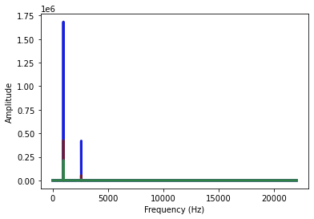

```python
spectrum1 = segment1.make_spectrum()
spectrum1.plot_power()
spectrum1.plot_power(color='#0000FF')
spectrum2 = segment2.make_spectrum()
spectrum2.plot_power()
spectrum2.plot_power(color='#8B0000')
spectrum3 = segment3.make_spectrum()
spectrum3.plot_power()
spectrum3.plot_power(color='#228B22')
thinkplot.config(xlabel='Frequency (Hz)',
                 ylabel='Amplitude')
```

Step 3: Calculating Spectrum of the three segments and plotting them(with log scaling)  
log is used to check amplitude drop with frequency

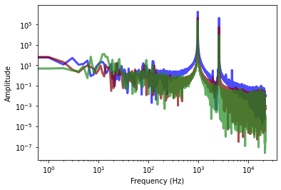

```python
spectrum1.plot_power(color='#0000FF')
spectrum2.plot_power(color='#8B0000')
spectrum3.plot_power(color='#228B22')
thinkplot.config(xlabel='Frequency (Hz)',
                 ylabel='Amplitude',
                 xscale='log',
                 yscale='log')
```

[figure not shown]

```python
segment.make_spectrogram(512).plot(high=5000)
```